# Bayesian GLMM Part5

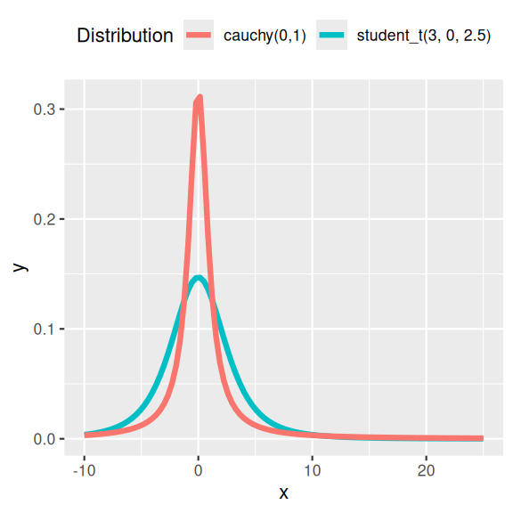

```r
standist::visualize("student_t(3, 0, 2.5)",
  "cauchy(0,1)",
  xlim = c(-10, 25)
)
```

**MCMC sampling diagnostics**

**bayesplot**

The `bayesplot` package offers a range of MCMC diagnostics as well as Posterior Probability Checks (PPC), all of which have a convenient `plot()` interface. Lets start with the MCMC diagnostics.

```r
available_mcmc()
```

```
bayesplot MCMC module:
  mcmc_acf
  mcmc_acf_bar
  mcmc_areas
  mcmc_areas_ridges
  mcmc_combo
  mcmc_dens
  mcmc_dens_chains
  mcmc_dens_overlay
  mcmc_hex
  mcmc_hist
  mcmc_hist_by_chain
  mcmc_intervals
  mcmc_neff
  mcmc_neff_hist
  mcmc_nuts_acceptance
  mcmc_nuts_divergence
  mcmc_nuts_energy
  mcmc_nuts_stepsize
  mcmc_nuts_treedepth
  mcmc_pairs
  mcmc_parcoord
  mcmc_rank_ecdf
  mcmc_rank_hist
  mcmc_rank_overlay
  mcmc_recover_hist
  mcmc_recover_intervals
  mcmc_recover_scatter
  mcmc_rhat
  mcmc_rhat_hist
  mcmc_scatter
  mcmc_trace
  mcmc_trace_highlight
  mcmc_violin
```

Of these, we will focus on:

- trace: this plots the estimates of each parameter over the post-warmup length of each MCMC chain. Each chain is plotted in a different shade of blue, with each parameter in its own facet. Ideally, each **trace** should just look like noise without any discernible drift and each of the traces for a specific parameter should look the same (i.e, should not be displaced above or below any other trace for that parameter).

```r
pars <- owls_brm1b |> get_variables()
pars <- pars |>
  str_extract("^b.Intercept|^b_FoodTreatment.*|^b_SexParent.*|[sS]igma|^sd.*") |>
  na.omit()
pars
```

```
[1] "b_Intercept"        "sd_Nest__Intercept"
attr(,"na.action")
 [1]  3  4  5  6  7  8  9 10 11 12 13 14 15 16 17 18 19 20 21 22 23 24 25 26 27
[26] 28 29 30 31 32 33 34 35 36 37 38 39 40
attr(,"class")
[1] "omit"
```

```
No divergences to plot.
```

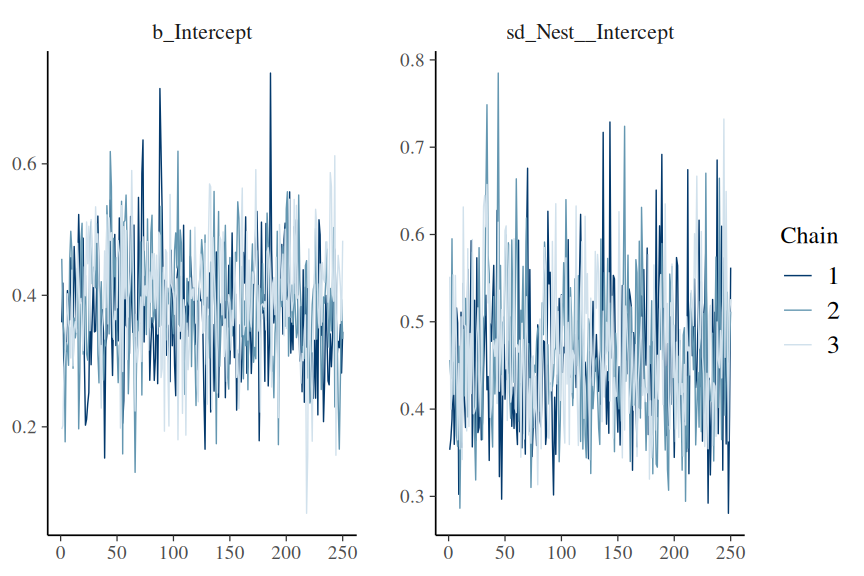

```r
owls_brm1b |> mcmc_plot(type = "trace", variable = pars)
```

```
No divergences to plot.
```

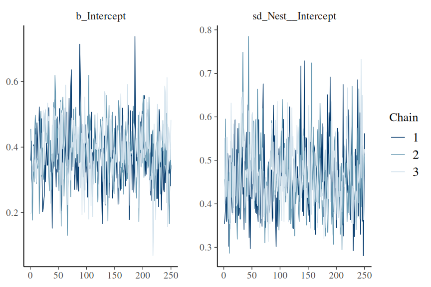

```r
## OR
owls_brm1b |> mcmc_plot(
  type = "trace",
  variable = "^b.Intercept|^b_FoodTreatment.*|^b_SexParent.*|[sS]igma|^sd.*",
  regex = TRUE
)
```

The chains appear well mixed and very similar

- acf_bar (auto-correlation function): plots the auto-correlation between successive MCMC sample lags for each parameter and each chain

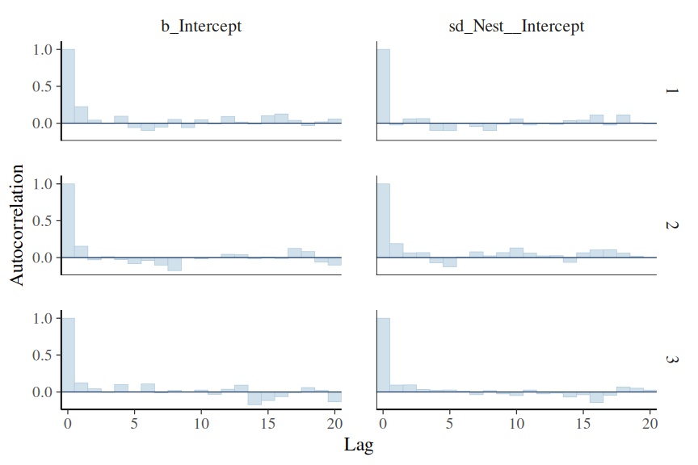

```r
owls_brm1b |> mcmc_plot(type = "acf_bar", variable = pars)
```

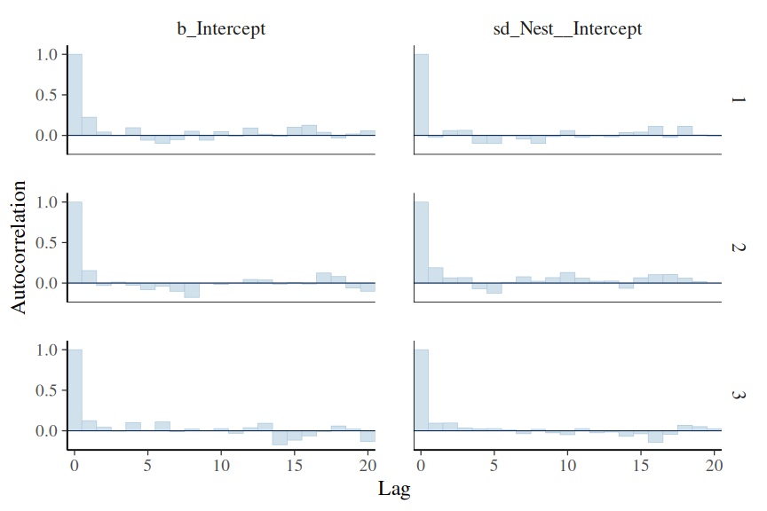

```r
## OR
owls_brm1b |> mcmc_plot(
  type = "acf_bar",
  variable = "^b.Intercept|^b_FoodTreatment.*|^b_SexParent.*|[sS]igma|^sd.*",
  regex = TRUE
)
```

There is no evidence of auto-correlation in the MCMC samples

- rhat_hist: Rhat is a **scale reduction factor** measure of convergence between the chains. The closer the values are to 1, the more the chains have converged. Values greater than 1.05 indicate a lack of convergence. There will be an Rhat value for each parameter estimated.

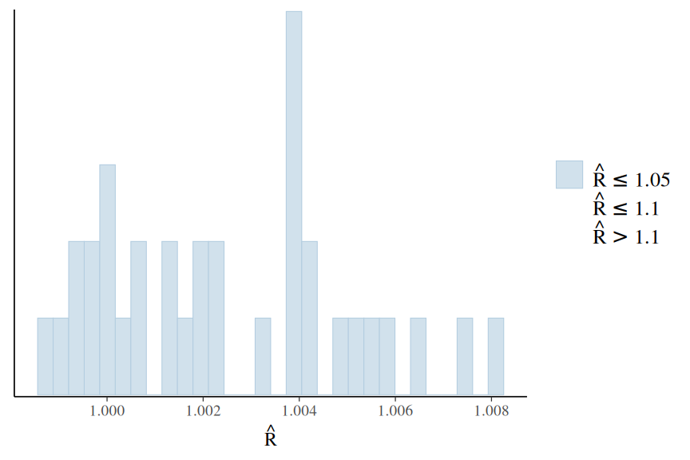

```r
owls_brm1b |> mcmc_plot(type = "rhat_hist")
```

All Rhat values are below 1.05, suggesting the chains have converged.

- neff_hist (number of effective samples): the ratio of the number of effective samples (those not rejected by the sampler) to the number of samples provides an indication of the effectiveness (and efficiency) of the MCMC sampler. Ratios that are less than 0.5 for a parameter suggest that the sampler spent considerable time in difficult areas of the sampling domain and rejected more than half of the samples (replacing them with the previous effective sample).

  If the ratios are low, tightening the priors may help.

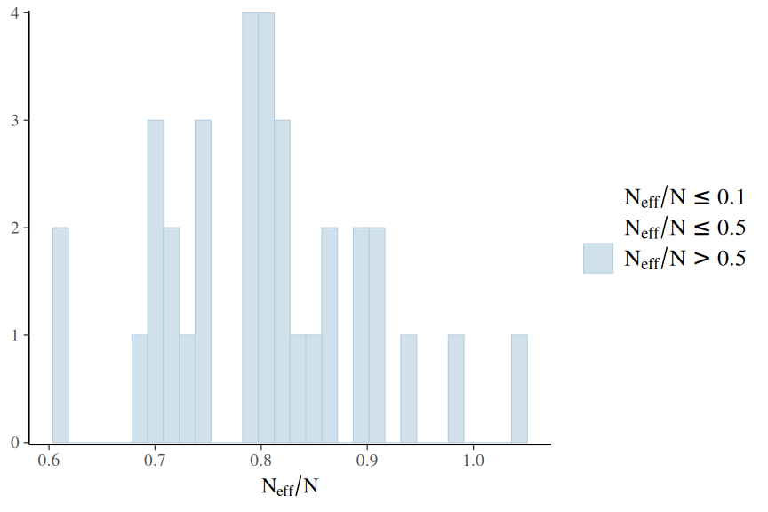

```r
owls_brm1b |> mcmc_plot(type = "neff_hist")
```

Ratios all very high.

**More diagnostics**

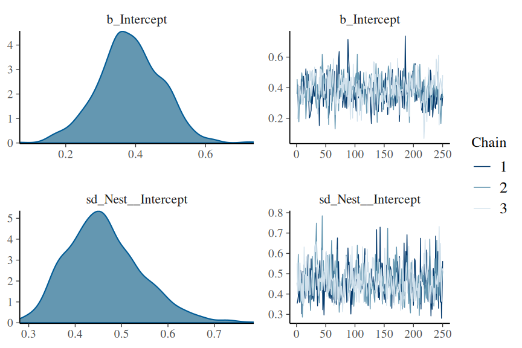

```r
owls_brm1b |> mcmc_plot(type = "combo", pars = pars)
```

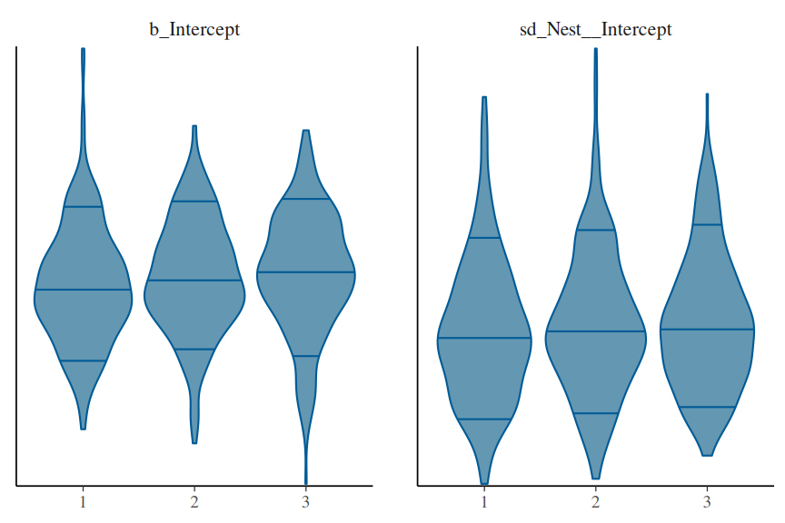

```r
owls_brm1b |> mcmc_plot(type = "violin", pars = pars)
```

**stan plots**

The `rstan` package offers a range of MCMC diagnostics. Lets start with the MCMC diagnostics.

Of these, we will focus on:

- stan_trace: this plots the estimates of each parameter over the post-warmup length of each MCMC chain. Each chain is plotted in a different colour, with each parameter in its own facet. Ideally, each **trace** should just look like noise without any discernible drift and each of the traces for a specific parameter should look the same (i.e, should not be displaced above or below any other trace for that parameter).

```r
owls_brm1b |> get_variables()
```

```
 [1] "b_Intercept"                       "sd_Nest__Intercept"
 [3] "Intercept"                         "r_Nest[AutavauxTV,Intercept]"
 [5] "r_Nest[Bochet,Intercept]"          "r_Nest[Champmartin,Intercept]"
 [7] "r_Nest[ChEsard,Intercept]"         "r_Nest[Chevroux,Intercept]"
 [9] "r_Nest[CorcellesFavres,Intercept]" "r_Nest[Etrabloz,Intercept]"
[11] "r_Nest[Forel,Intercept]"           "r_Nest[Franex,Intercept]"
[13] "r_Nest[GDLV,Intercept]"            "r_Nest[Gletterens,Intercept]"
[15] "r_Nest[Henniez,Intercept]"         "r_Nest[Jeuss,Intercept]"
[17] "r_Nest[LesPlanches,Intercept]"     "r_Nest[Lucens,Intercept]"
[19] "r_Nest[Lully,Intercept]"           "r_Nest[Marnand,Intercept]"
[21] "r_Nest[Montet,Intercept]"          "r_Nest[Murist,Intercept]"
[23] "r_Nest[Oleyes,Intercept]"          "r_Nest[Payerne,Intercept]"
[25] "r_Nest[Rueyes,Intercept]"          "r_Nest[Seiry,Intercept]"
[27] "r_Nest[Sevaz,Intercept]"           "r_Nest[StAubin,Intercept]"
[29] "r_Nest[Trey,Intercept]"            "r_Nest[Yvonnand,Intercept]"
[31] "prior_Intercept"                   "prior_sd_Nest"
[33] "lprior"                            "lp__"
[35] "accept_stat__"                     "stepsize__"
[37] "treedepth__"                       "n_leapfrog__"
[39] "divergent__"                       "energy__"
```

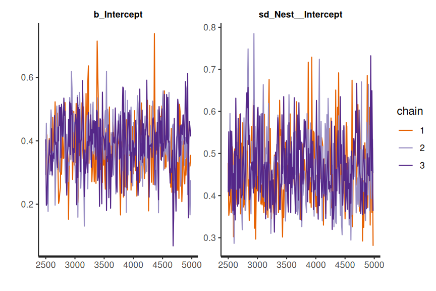

```r
pars <- owls_brm1b |> get_variables()
pars <- str_extract(pars, "^b_.*|^sigma$|^sd.*") |> na.omit()

owls_brm1b$fit |>
  stan_trace(pars = pars)
```

The chains appear well mixed and very similar

- stan_acf (auto-correlation function): plots the auto-correlation between successive MCMC sample lags for each parameter and each chain

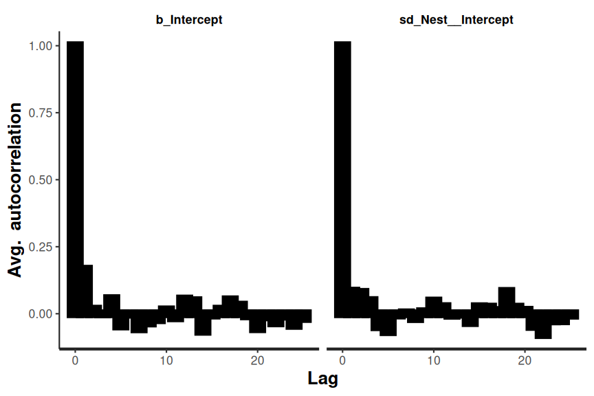

```r
owls_brm1b$fit |>
  stan_ac(pars = pars)
```

There is no evidence of auto-correlation in the MCMC samples

- stan_rhat: Rhat is a **scale reduction factor** measure of convergence between the chains. The closer the values are to 1, the more the chains have converged. Values greater than 1.05 indicate a lack of convergence. There will be an Rhat value for each parameter estimated.

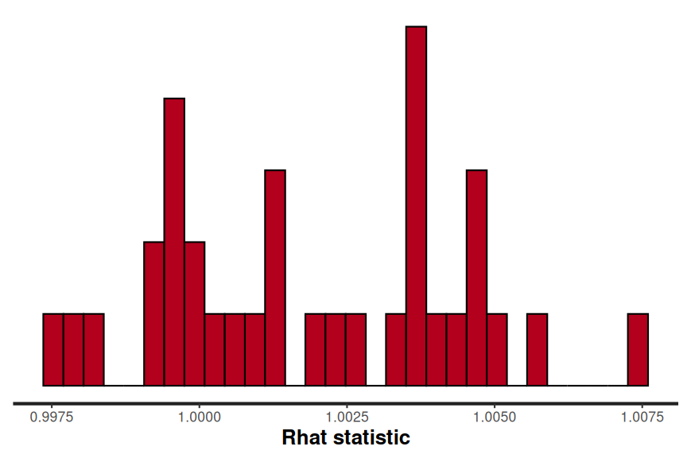

```r
owls_brm1b$fit |> stan_rhat()
```

All Rhat values are below 1.05, suggesting the chains have converged.

- stan_ess (number of effective samples): the ratio of the number of effective samples (those not rejected by the sampler) to the number of samples provides an indication of the effectiveness (and efficiency) of the MCMC sampler. Ratios that are less than 0.5 for a parameter suggest that the sampler spent considerable time in difficult areas of the sampling domain and rejected more than half of the samples (replacing them with the previous effective sample).

  If the ratios are low, tightening the priors may help.

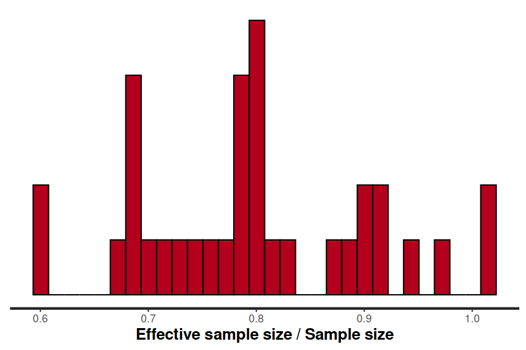

```r
owls_brm1b$fit |> stan_ess()
```

Ratios all very high.

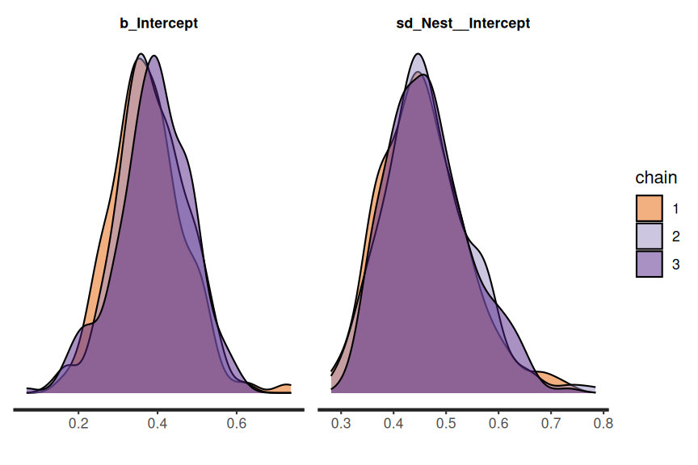

```r
owls_brm1b$fit |>
  stan_dens(separate_chains = TRUE, pars = pars)
```

**ggmcmc**

The `ggmean` package also as a set of MCMC diagnostic functions. Lets start with the MCMC diagnostics.

Of these, we will focus on:

- ggs_traceplot: this plots the estimates of each parameter over the post-warmup length of each MCMC chain. Each chain is plotted in a different colour, with each parameter in its own facet. Ideally, each **trace** should just look like noise without any discernible drift and each of the traces for a specific parameter should look the same (i.e, should not be displaced above or below any other trace for that parameter).

```r
## owls_ggs <- owls_brm3 |> ggs(burnin = FALSE, inc_warmup = FALSE)
## owls_ggs |> ggs_traceplot()
```

- gss_autocorrelation (autocorrelation function): plots the autocorrelation between successive MCMC sample lags for each parameter and each chain

```r
## ggs_autocorrelation(owls_ggs)
```

- stan_rhat: Rhat is a **scale reduction factor** measure of convergence between the chains. The closer the values are to 1, the more the chains have converged. Values greater than 1.05 indicate a lack of convergence. There will be an Rhat value for each parameter estimated.

```r
## ggs_Rhat(owls_ggs)
```

- stan_ess (number of effective samples): the ratio of the number of effective samples (those not rejected by the sampler) to the number of samples provides an indication of the effectiveness (and efficiency) of the MCMC sampler. Ratios that are less than 0.5 for a parameter suggest that the sampler spent considerable time in difficult areas of the sampling domain and rejected more than half of the samples (replacing them with the previous effective sample).

  If the ratios are low, tightening the priors may help.

```r
## ggs_effective(owls_ggs)
```

**More diagnostics**

```r
## ggs_crosscorrelation(owls_ggs)
```

```r
## ggs_grb(owls_ggs)
```

**Model validation**

**pp check**

Post predictive checks provide additional diagnostics about the fit of the model. Specifically, they provide a comparison between predictions drawn from the model and the observed data used to train the model.

```r
available_ppc()
```

```
bayesplot PPC module:
  ppc_bars
  ppc_bars_grouped
  ppc_boxplot
  ppc_dens
  ppc_dens_overlay
  ppc_dens_overlay_grouped
  ppc_dots
  ppc_ecdf_overlay
  ppc_ecdf_overlay_grouped
  ppc_error_binned
  ppc_error_hist
  ppc_error_hist_grouped
  ppc_error_scatter
  ppc_error_scatter_avg
  ppc_error_scatter_avg_grouped
  ppc_error_scatter_avg_vs_x
  ppc_freqpoly
  ppc_freqpoly_grouped
  ppc_hist
  ppc_intervals
  ppc_intervals_grouped
  ppc_km_overlay
  ppc_km_overlay_grouped
  ppc_loo_intervals
  ppc_loo_pit_ecdf
  ppc_loo_pit_overlay
  ppc_loo_pit_qq
  ppc_loo_ribbon
  ppc_pit_ecdf
  ppc_pit_ecdf_grouped
  ppc_ribbon
  ppc_ribbon_grouped
  ppc_rootogram
  ppc_scatter
  ppc_scatter_avg
  ppc_scatter_avg_grouped
  ppc_stat
  ppc_stat_2d
  ppc_stat_freqpoly
  ppc_stat_freqpoly_grouped
  ppc_stat_grouped
  ppc_violin_grouped
```

- dens_overlay: plots the density distribution of the observed data (black line) overlayed on top of 50 density distributions generated from draws from the model (light blue). Ideally, the 50 realisations should be roughly consistent with the observed data.

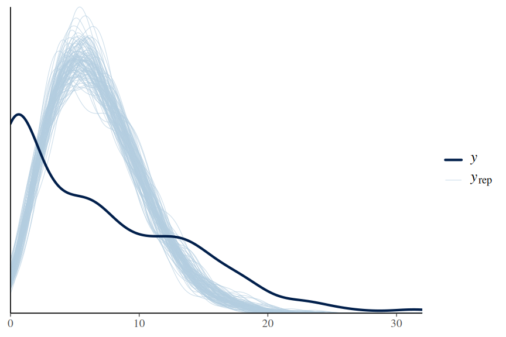

```r
owls_brm1b |> pp_check(type = "dens_overlay", ndraws = 100)
```

The model draws appear to differ substantially from the observed data.

- error_scatter_avg: this plots the observed values against the average residuals. Similar to a residual plot, we do not want to see any patterns in this plot. Note, this is not really that useful for models that involve a binomial response

```r
## owls_brm1b |> pp_check(type = 'error_scatter_avg')
```

This is not really interpretable

- intervals: plots the observed data overlayed on top of posterior predictions associated with each level of the predictor. Ideally, the observed data should all fall within the predictive intervals.

```
Using all posterior draws for ppc type 'intervals' by default.
```

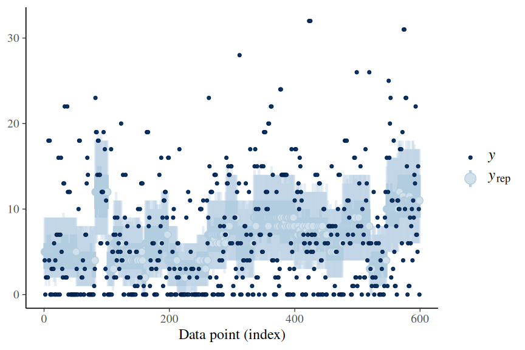

```r
owls_brm1b |> pp_check(group = "Nest", type = "intervals")
```

The `shinystan` package allows the full suite of MCMC diagnostics and posterior predictive checks to be accessed via a web interface.

```r
# library(shinystan)
# launch_shinystan(owls_brm2)
```

**DHARMa residuals**

DHARMa residuals provide very useful diagnostics. Unfortunately, we cannot directly use the `simulateResiduals()` function to generate the simulated residuals. However, if we are willing to calculate some of the components yourself, we can still obtain the simulated residuals from the fitted stan model.

We need to supply:

- simulated (predicted) responses associated with each observation.
- observed values
- fitted (predicted) responses (averaged) associated with each observation

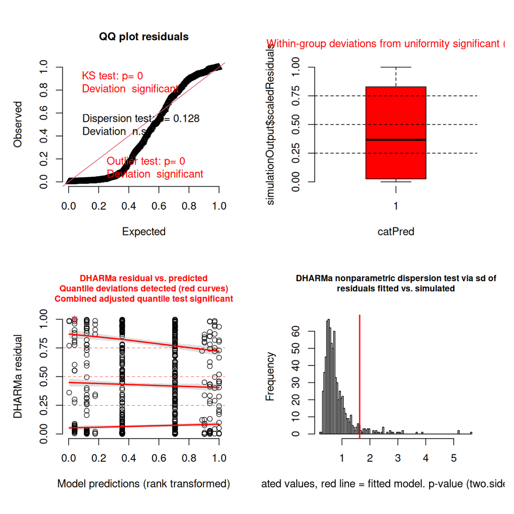

```r
owls_resids <- make_brms_dharma_res(owls_brm1b, integerResponse = TRUE)
wrap_elements(~ testUniformity(owls_resids)) +
  wrap_elements(~ plotResiduals(owls_resids, form = factor(rep(1, nrow(owls))))) +
  wrap_elements(~ plotResiduals(owls_resids, quantreg = TRUE)) +
  wrap_elements(~ testDispersion(owls_resids))
```

**Conclusions:**

- the model does not appear to be a very good fit
- the Q-Q plot deviates substantially from a straight line
- there are outliers

Perhaps we should specifically explore zero-inflation.

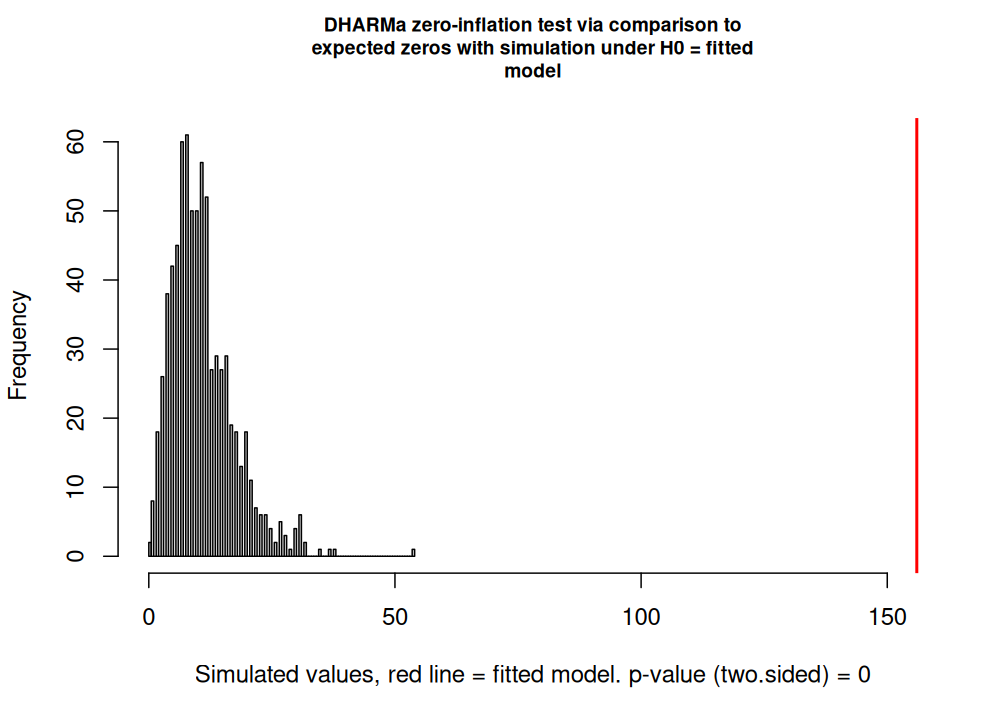

```
    DHARMa zero-inflation test via comparison to expected zeros with
    simulation under H0 = fitted model

data:  simulationOutput
ratioObsSim = 14.022, p-value < 2.2e-16
alternative hypothesis: two.sided
```

```r
owls_resids |> testZeroInflation()
```

**Conclusions:**

- there is strong evidence of zero-inflation

The data were collected at various times throughout the night. It is possible that this could lead to patterns of dependency that are not already accounted for. For example, perhaps observations that are collected at similar time of the night (within a given nest) have more similar residuals than those at very different time of the night. We can explore whether there are any temporal auto-correlation patterns.

```r
owls_resids |> testTemporalAutocorrelation(time = owls$ArrivalTime)
```

[output not shown]

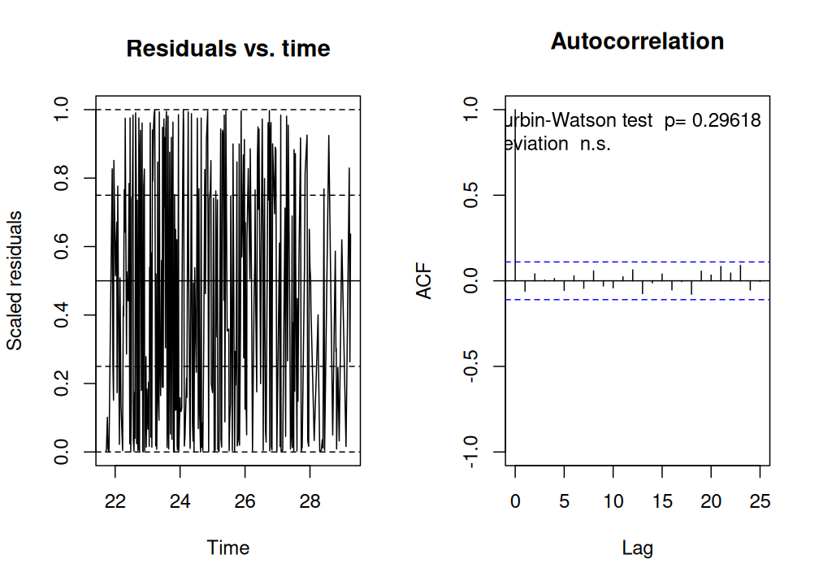

```
    Durbin-Watson test

data:  simulationOutput$scaledResiduals ~ 1
DW = 2.117, p-value = 0.2962
alternative hypothesis: true autocorrelation is not 0
```

```r
## owls_resid1 <- owls_resids |> recalculateResiduals(group=interaction(owls$ArrivalTime,  owls$Nest),  aggregateBy = mean)
## owls_resid1 <- owls_resids |> recalculateResiduals(group=interaction(owls$ArrivalTime,  owls$Nest),  aggregateBy = sum)
## resids1 <- owls_resids |> recalculateResiduals(group = interaction(owls$ArrivalTime), aggregateBy = sum)
resids1 <- owls_resids |> recalculateResiduals(group = interaction(owls$ArrivalTime), aggregateBy = mean)
resids1 |> testTemporalAutocorrelation(time = unique(owls$ArrivalTime))
```

[output not shown]

[output cut: 447 more lines]

[output not shown]

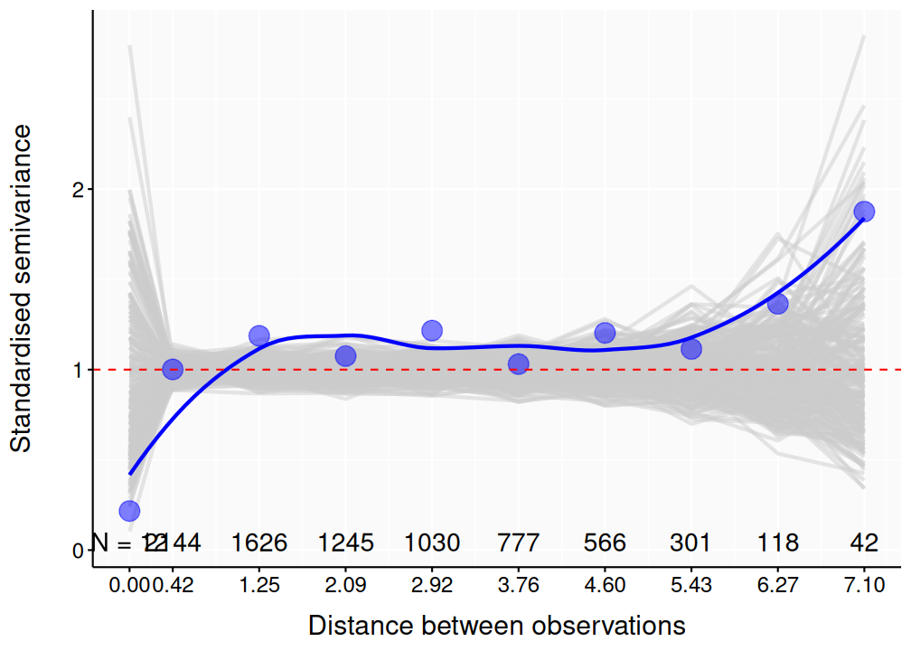

```r
autocor_check(owls, owls_brm1b,
  variable = "ArrivalTime",
  grouping = "Nest",
  n.sim = 250
)
```

**Conclusions:**

- there is no evidence of temporal auto-correlation

**Conclusions:**

**Model 2**

**Zero-inflated vs hurdle models**

- zero-inflated models: are a mixture of Bernoulli and Poisson (or negative binomial) distributions to model situations where it is believed that the observed data are the result of two combined processes (a count process that governs how many items there are to count and a Bernoulli process that governs whether the items are detectable). In this way, zero-inflated models are useful in situations where we believe that some of the zeros are false zeros (recorded as zeros when they should not have been).
- hurdle models: are for situations where the response itself is thought to be the result of two processes: one that governs whether there is a response and then another that governs the value of the response (must be positive).

**Fit model**

```r
owls_form <- bf(
  NCalls ~ +
    offset(log(BroodSize)) + (1 | Nest),
  zi = ~1,
  family = zero_inflated_poisson(link = "log")
)
options(width = 150)
owls_form |> get_prior(data = owls)
```

```
                               prior     class      coef group resp dpar nlpar lb ub       source
 student_t(3, 0.16097150412244, 2.5) Intercept                                            default
                student_t(3, 0, 2.5)        sd                                  0         default
                student_t(3, 0, 2.5)        sd            Nest                  0    (vectorized)
                student_t(3, 0, 2.5)        sd Intercept  Nest                  0    (vectorized)
                      logistic(0, 1) Intercept                        zi                  default
```

```r
options(width = 80)
owls |>
  summarise(
    Mean = log(median(NCalls / BroodSize)),
    SD = log(sd(NCalls / BroodSize)),
    MAD = log(mad(NCalls / BroodSize))
  )
```

```
# A tibble: 1 × 3
   Mean    SD   MAD
  <dbl> <dbl> <dbl>
1 0.182 0.479 0.576
```

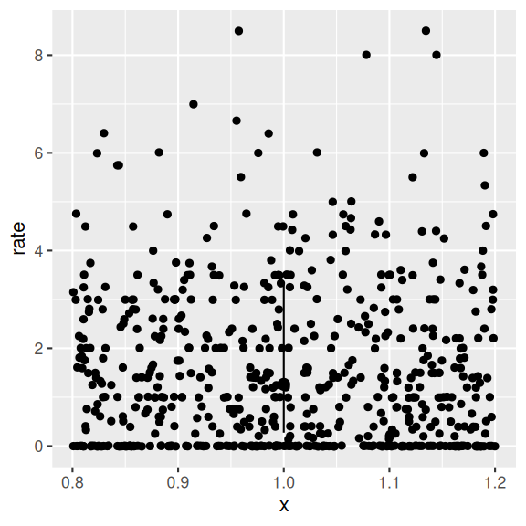

```r
priors <- prior(normal(0.2, 0.6), class = "Intercept") +
  prior(student_t(3, 0, 0.6), class = "sd") +
  prior(normal(0, 1), class = "Intercept", dpar = "zi")
owls_brm2a <- brm(owls_form,
  data = owls,
  prior = priors,
  sample_prior = "only",
  iter = 5000,
  warmup = 2500,
  chains = 3,
  cores = 3,
  thin = 10,
  refresh = 0,
  seed = 123,
  control = list(adapt_delta = 0.99),
  backend = "rstan"
)
owls_brm2a |>
  emmeans(~1, type = "response") |>
  as.data.frame() |>
  ggplot(aes(x = 1, y = rate)) +
  geom_pointrange(aes(ymin = lower.HPD, ymax = upper.HPD)) +
  geom_point(
    data = owls, aes(y = NCalls / BroodSize),
    position = position_jitter(width = 0.2)
  )
```

```r
owls_brm2b <- update(owls_brm2a,
  sample_prior = "yes",
  iter = 5000,
  warmup = 2500,
  control = list(adapt_delta = 0.99, max_treedepth = 20),
  backend = "rstan",
  refresh = 0
)
```

```
The desired updates require recompiling the model
```

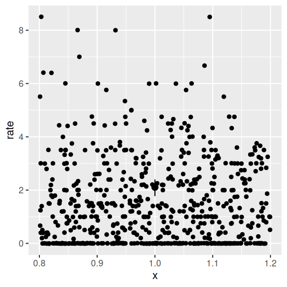

```r
owls_brm2b |>
  emmeans(~1, type = "response") |>
  as.data.frame() |>
  ggplot(aes(x = 1, y = rate)) +
  geom_pointrange(aes(ymin = lower.HPD, ymax = upper.HPD)) +
  geom_point(
    data = owls, aes(y = NCalls / BroodSize),
    position = position_jitter(width = 0.2)
  )
```

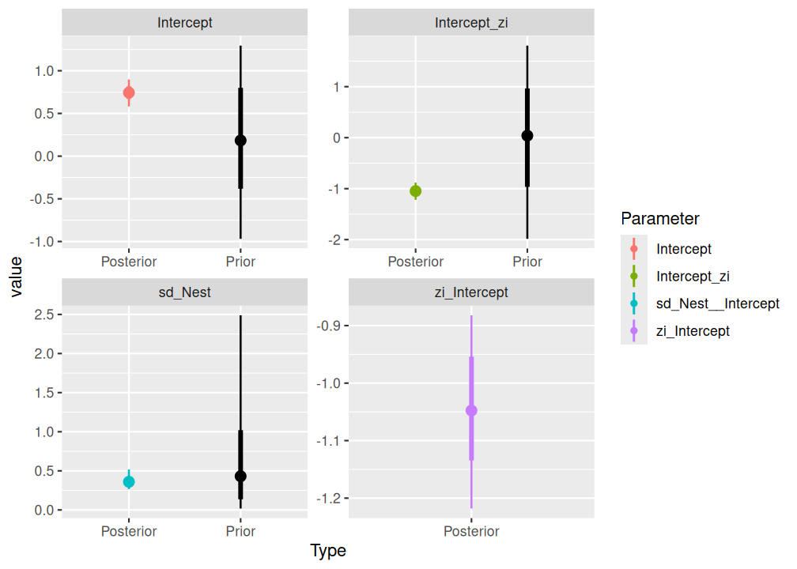

```r
owls_brm2b |> SUYR_prior_and_posterior()
```

**MCMC sampling diagnostics**

```r
owls_brm2b |> get_variables()
```

```
 [1] "b_Intercept"                       "b_zi_Intercept"
 [3] "sd_Nest__Intercept"                "Intercept"
 [5] "Intercept_zi"                      "r_Nest[AutavauxTV,Intercept]"
 [7] "r_Nest[Bochet,Intercept]"          "r_Nest[Champmartin,Intercept]"
 [9] "r_Nest[ChEsard,Intercept]"         "r_Nest[Chevroux,Intercept]"
[11] "r_Nest[CorcellesFavres,Intercept]" "r_Nest[Etrabloz,Intercept]"
[13] "r_Nest[Forel,Intercept]"           "r_Nest[Franex,Intercept]"
[15] "r_Nest[GDLV,Intercept]"            "r_Nest[Gletterens,Intercept]"
[17] "r_Nest[Henniez,Intercept]"         "r_Nest[Jeuss,Intercept]"
[19] "r_Nest[LesPlanches,Intercept]"     "r_Nest[Lucens,Intercept]"
[21] "r_Nest[Lully,Intercept]"           "r_Nest[Marnand,Intercept]"
[23] "r_Nest[Montet,Intercept]"          "r_Nest[Murist,Intercept]"
[25] "r_Nest[Oleyes,Intercept]"          "r_Nest[Payerne,Intercept]"
[27] "r_Nest[Rueyes,Intercept]"          "r_Nest[Seiry,Intercept]"
[29] "r_Nest[Sevaz,Intercept]"           "r_Nest[StAubin,Intercept]"
[31] "r_Nest[Trey,Intercept]"            "r_Nest[Yvonnand,Intercept]"
[33] "prior_Intercept"                   "prior_Intercept_zi"
[35] "prior_sd_Nest"                     "lprior"
[37] "lp__"                              "accept_stat__"
[39] "stepsize__"                        "treedepth__"
[41] "n_leapfrog__"                      "divergent__"
[43] "energy__"
```

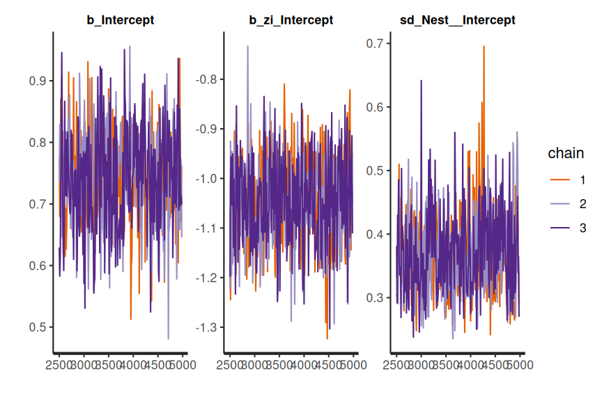

```r
pars <- owls_brm2b |> get_variables()
pars <- str_extract(pars, "^b_.*|^sigma$|^sd.*") |> na.omit()

owls_brm2b$fit |>
  stan_trace(pars = pars)
```

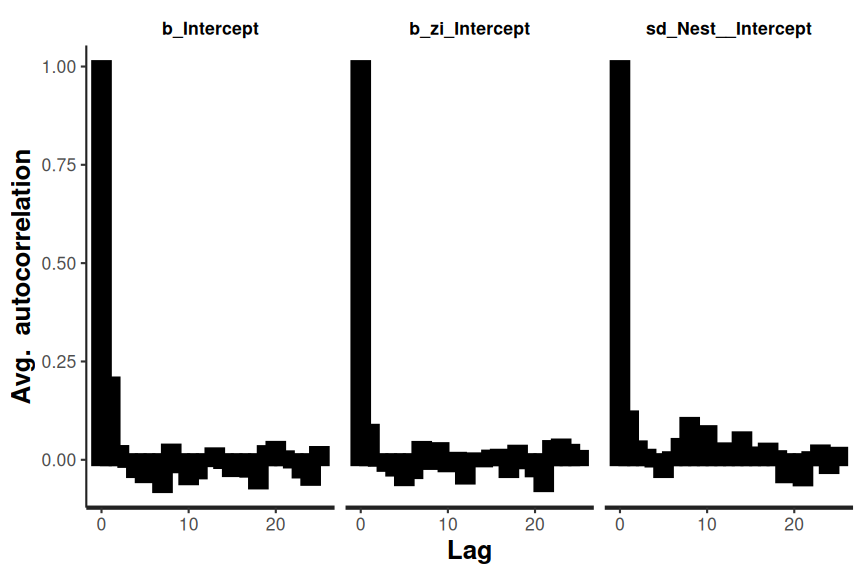

```r
owls_brm2b$fit |>
  stan_ac(pars = pars)
```

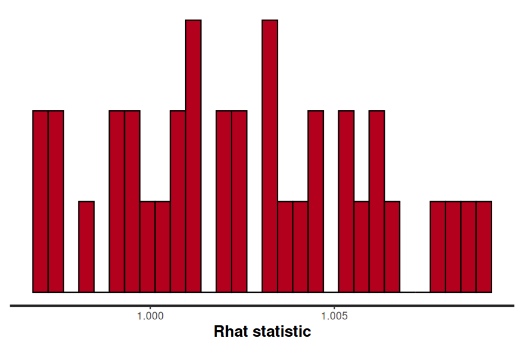

```r
owls_brm2b$fit |> stan_rhat()
```

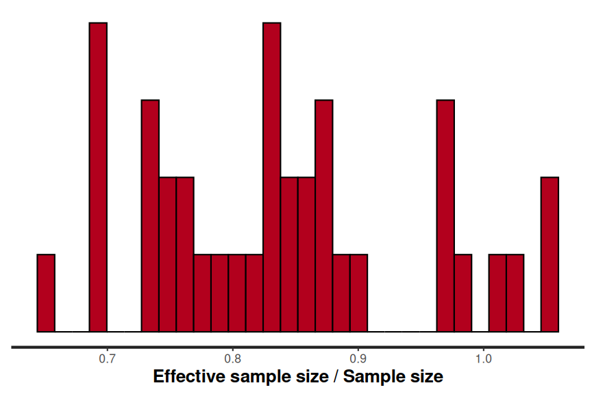

```r
owls_brm2b$fit |> stan_ess()
```

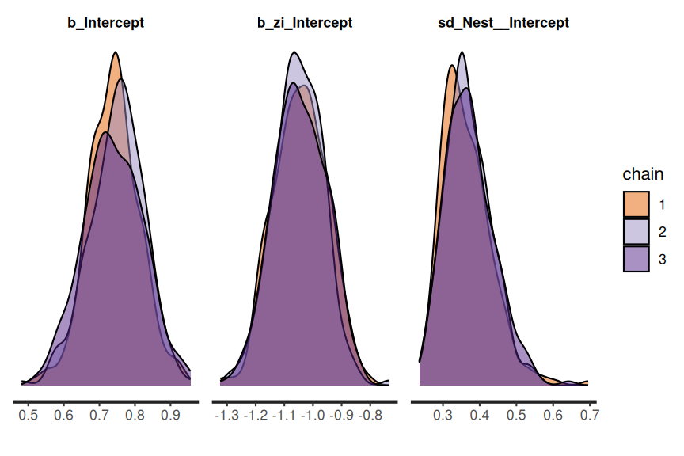

```r
owls_brm2b$fit |>
  stan_dens(separate_chains = TRUE, pars = pars)
```

**Model validation**

**pp check**

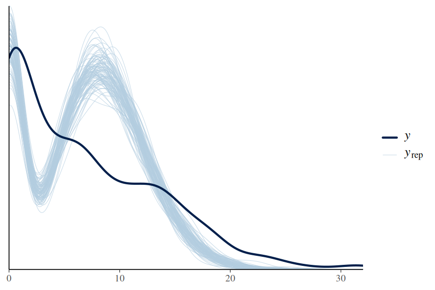

```r
owls_brm2b |> pp_check(type = "dens_overlay", ndraws = 100)
```

```r
## owls_brm2b |> pp_check(type = 'error_scatter_avg')
```

```
Using all posterior draws for ppc type 'intervals' by default.
```

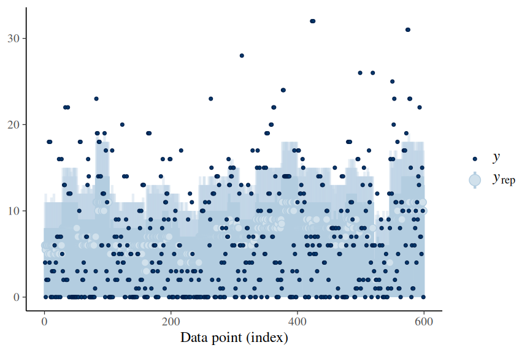

```r
owls_brm2b |> pp_check(group = "Nest", type = "intervals")
```

**DHARMa residuals**

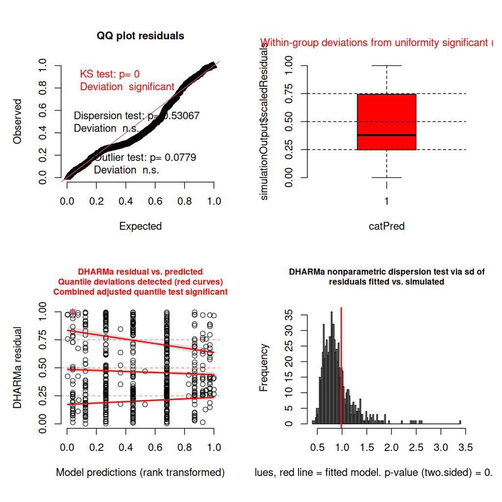

```r
owls_resids <- make_brms_dharma_res(owls_brm2b, integerResponse = TRUE)
wrap_elements(~ testUniformity(owls_resids)) +
  wrap_elements(~ plotResiduals(owls_resids, form = factor(rep(1, nrow(owls))))) +
  wrap_elements(~ plotResiduals(owls_resids, quantreg = TRUE)) +
  wrap_elements(~ testDispersion(owls_resids))
```

**Model 3**

**Fit model**

```r
owls_form <- bf(
  NCalls ~ +
    offset(log(BroodSize)) + (1 | Nest),
  zi = ~1,
  family = zero_inflated_negbinomial(link = "log")
)
options(width = 150)
owls_form |> get_prior(data = owls)
```

```
                               prior     class      coef group resp dpar nlpar lb ub       source
 student_t(3, 0.16097150412244, 2.5) Intercept                                            default
                student_t(3, 0, 2.5)        sd                                  0         default
                student_t(3, 0, 2.5)        sd            Nest                  0    (vectorized)
                student_t(3, 0, 2.5)        sd Intercept  Nest                  0    (vectorized)
                   gamma(0.01, 0.01)     shape                                  0         default
                      logistic(0, 1) Intercept                        zi                  default
```

```r
options(width = 80)
owls |>
  summarise(
    Mean = log(median(NCalls / BroodSize)),
    SD = log(sd(NCalls / BroodSize)),
    MAD = log(mad(NCalls / BroodSize))
  )
```

```
# A tibble: 1 × 3
   Mean    SD   MAD
  <dbl> <dbl> <dbl>
1 0.182 0.479 0.576
```

```r
priors <- prior(normal(0.2, 0.6), class = "Intercept") +
  prior(student_t(3, 0, 0.6), class = "sd") +
  prior(normal(0, 1), class = "Intercept", dpar = "zi") +
  prior(gamma(0.01, 0.01), class = "shape")
owls_brm3a <- brm(owls_form,
  data = owls,
  prior = priors,
  sample_prior = "only",
  iter = 5000,
  warmup = 2500,
  chains = 3,
  cores = 3,
  thin = 10,
  refresh = 0,
  seed = 123,
  control = list(adapt_delta = 0.99),
  backend = "rstan"
)
```

```r
owls_brm3b <- update(owls_brm3a,
  sample_prior = "yes",
  iter = 5000,
  warmup = 2500,
  control = list(adapt_delta = 0.99, max_treedepth = 20),
  backend = "rstan",
  refresh = 0
)
```

```
The desired updates require recompiling the model
```

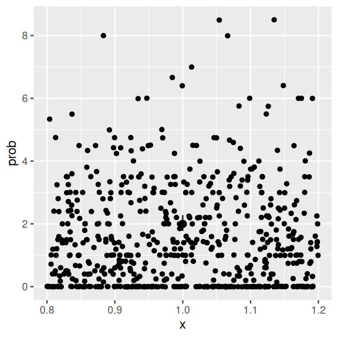

```r
owls_brm3b |>
  emmeans(~1, type = "response") |>
  as.data.frame() |>
  ggplot(aes(x = 1, y = prob)) +
  geom_pointrange(aes(ymin = lower.HPD, ymax = upper.HPD)) +
  geom_point(
    data = owls, aes(y = NCalls / BroodSize),
    position = position_jitter(width = 0.2)
  )
```

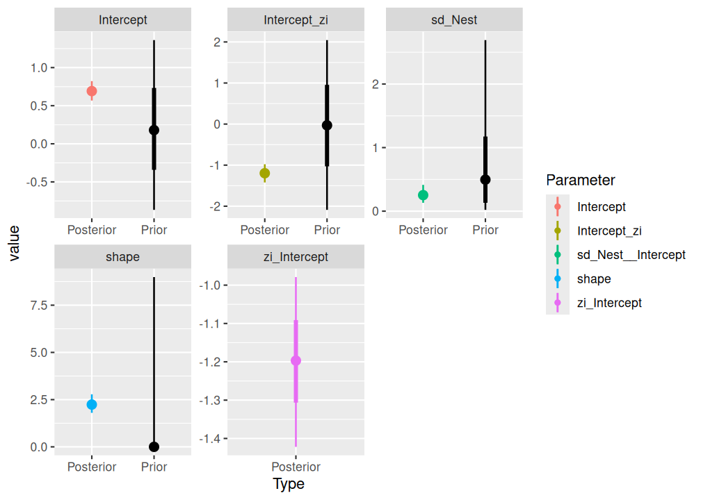

```r
owls_brm3b |> SUYR_prior_and_posterior()
```

**MCMC sampling diagnostics**

```r
owls_brm3b |> get_variables()
```

```
 [1] "b_Intercept"                       "b_zi_Intercept"
 [3] "sd_Nest__Intercept"                "shape"
 [5] "Intercept"                         "Intercept_zi"
 [7] "r_Nest[AutavauxTV,Intercept]"      "r_Nest[Bochet,Intercept]"
 [9] "r_Nest[Champmartin,Intercept]"     "r_Nest[ChEsard,Intercept]"
[11] "r_Nest[Chevroux,Intercept]"        "r_Nest[CorcellesFavres,Intercept]"
[13] "r_Nest[Etrabloz,Intercept]"        "r_Nest[Forel,Intercept]"
[15] "r_Nest[Franex,Intercept]"          "r_Nest[GDLV,Intercept]"
[17] "r_Nest[Gletterens,Intercept]"      "r_Nest[Henniez,Intercept]"
[19] "r_Nest[Jeuss,Intercept]"           "r_Nest[LesPlanches,Intercept]"
[21] "r_Nest[Lucens,Intercept]"          "r_Nest[Lully,Intercept]"
[23] "r_Nest[Marnand,Intercept]"         "r_Nest[Montet,Intercept]"
[25] "r_Nest[Murist,Intercept]"          "r_Nest[Oleyes,Intercept]"
[27] "r_Nest[Payerne,Intercept]"         "r_Nest[Rueyes,Intercept]"
[29] "r_Nest[Seiry,Intercept]"           "r_Nest[Sevaz,Intercept]"
[31] "r_Nest[StAubin,Intercept]"         "r_Nest[Trey,Intercept]"
[33] "r_Nest[Yvonnand,Intercept]"        "prior_Intercept"
[35] "prior_shape"                       "prior_Intercept_zi"
[37] "prior_sd_Nest"                     "lprior"
[39] "lp__"                              "accept_stat__"
[41] "stepsize__"                        "treedepth__"
[43] "n_leapfrog__"                      "divergent__"
[45] "energy__"
```

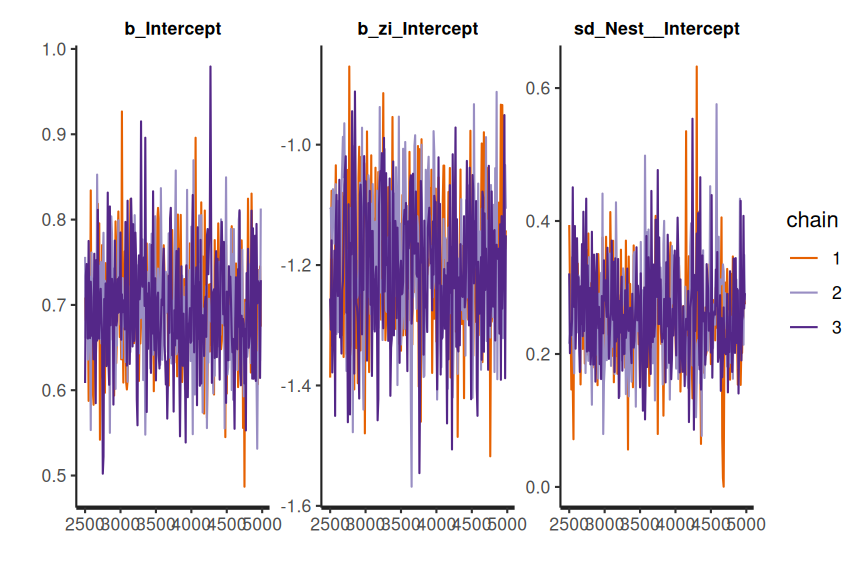

```r
pars <- owls_brm3b |> get_variables()
pars <- str_extract(pars, "^b_.*|^sigma$|^sd.*") |> na.omit()

owls_brm3b$fit |>
  stan_trace(pars = pars)
```

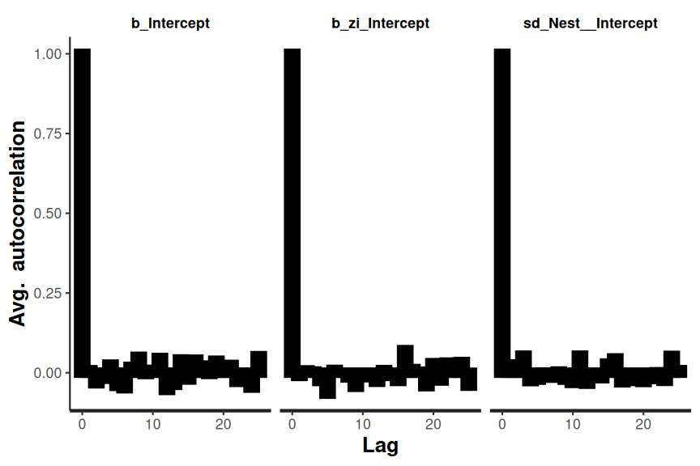

```r
owls_brm3b$fit |>
  stan_ac(pars = pars)
```

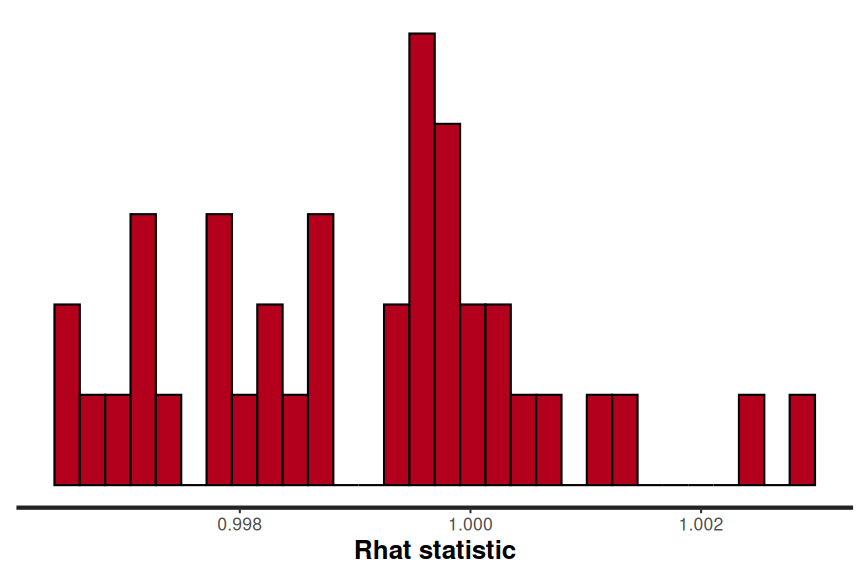

```r
owls_brm3b$fit |> stan_rhat()
```

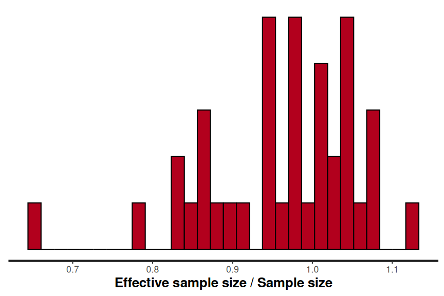

```r
owls_brm3b$fit |> stan_ess()
```

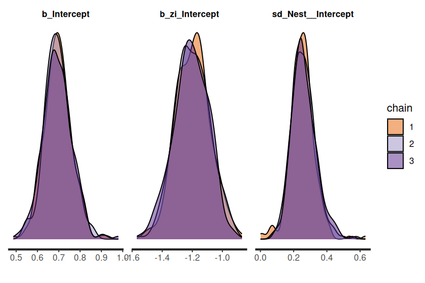

```r
owls_brm3b$fit |>
  stan_dens(separate_chains = TRUE, pars = pars)
```

**Model validation**

**pp check**

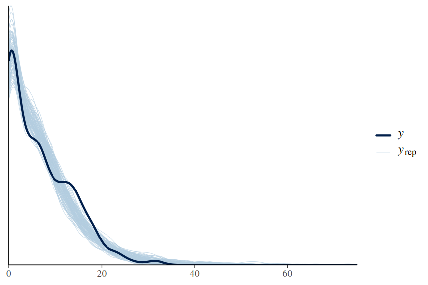

```r
owls_brm3b |> pp_check(type = "dens_overlay", ndraws = 100)
```

```r
## owls_brm3b |> pp_check(type = 'error_scatter_avg')
```

```
Using all posterior draws for ppc type 'intervals' by default.
```

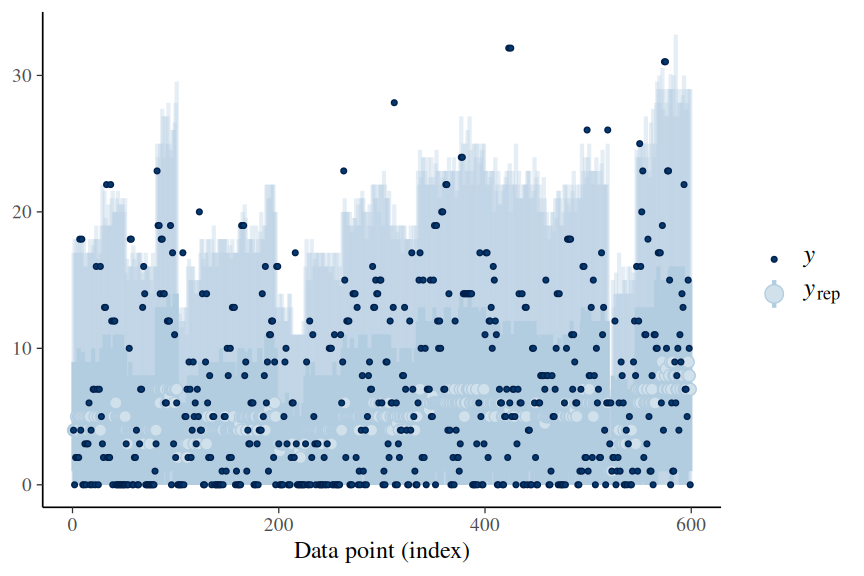

```r
owls_brm3b |> pp_check(group = "Nest", type = "intervals")
```

**DHARMa residuals**

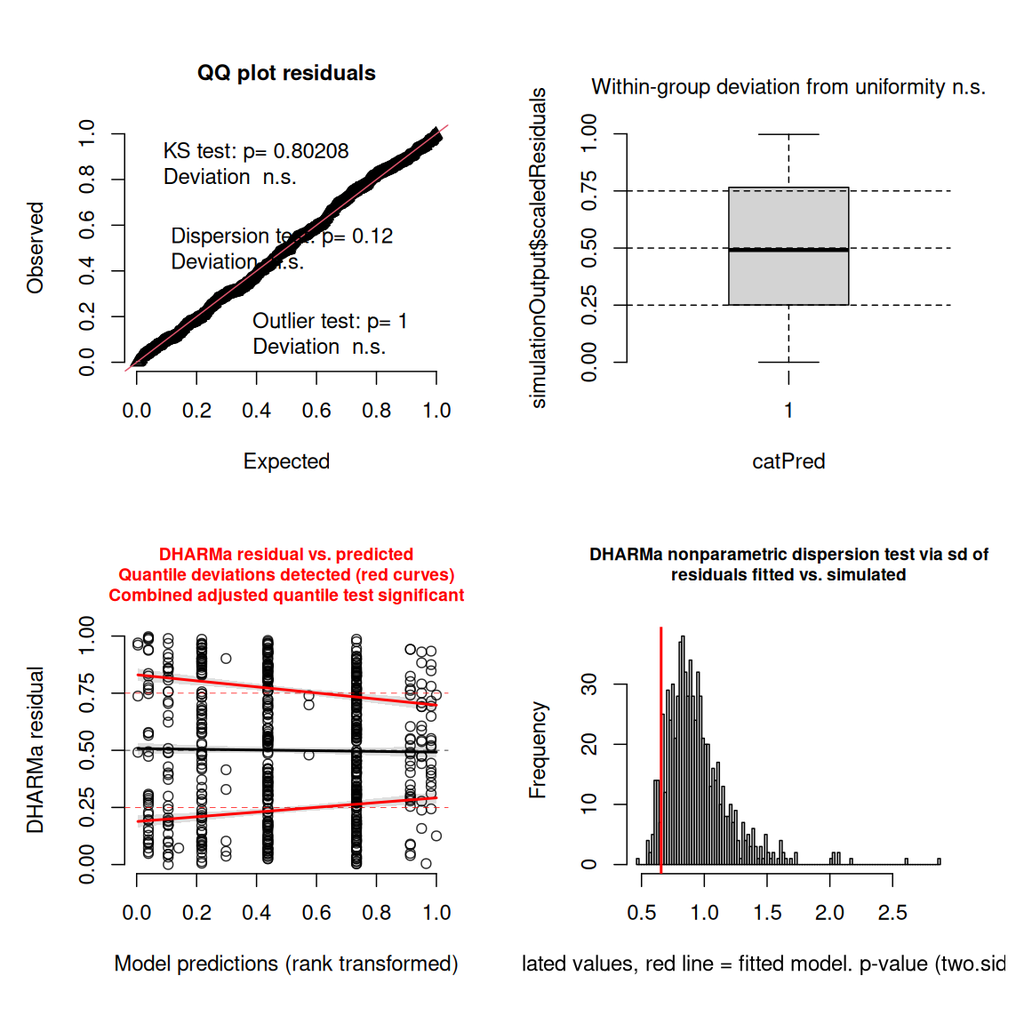

```r
owls_resids <- make_brms_dharma_res(owls_brm3b, integerResponse = TRUE)
wrap_elements(~ testUniformity(owls_resids)) +
  wrap_elements(~ plotResiduals(owls_resids, form = factor(rep(1, nrow(owls))))) +
  wrap_elements(~ plotResiduals(owls_resids, quantreg = TRUE)) +
  wrap_elements(~ testDispersion(owls_resids))
```

**Model 4**

**Fit model**

```r
owls_form <- bf(
  NCalls ~ FoodTreatment * SexParent +
    offset(log(BroodSize)) + (1 | Nest),
  zi = ~1,
  family = zero_inflated_negbinomial(link = "log")
)
options(width = 150)
owls_form |> get_prior(data = owls)
```

```
                               prior     class                                coef group resp dpar nlpar lb ub       source
                              (flat)         b                                                                      default
                              (flat)         b               FoodTreatmentSatiated                             (vectorized)
                              (flat)         b FoodTreatmentSatiated:SexParentMale                             (vectorized)
                              (flat)         b                       SexParentMale                             (vectorized)
 student_t(3, 0.16097150412244, 2.5) Intercept                                                                      default
                student_t(3, 0, 2.5)        sd                                                            0         default
                student_t(3, 0, 2.5)        sd                                      Nest                  0    (vectorized)
                student_t(3, 0, 2.5)        sd                           Intercept  Nest                  0    (vectorized)
                   gamma(0.01, 0.01)     shape                                                            0         default
                      logistic(0, 1) Intercept                                                  zi                  default
```

```r
options(width = 80)
owls |>
  group_by(FoodTreatment, SexParent) |>
  summarise(
    Mean = log(median(NCalls / BroodSize)),
    SD = log(sd(NCalls / BroodSize)),
    MAD = log(mad(NCalls / BroodSize))
  )
```

```
# A tibble: 4 × 5
# Groups:   FoodTreatment [2]
  FoodTreatment SexParent   Mean    SD    MAD
  <fct>         <fct>      <dbl> <dbl>  <dbl>
1 Deprived      Female     0.405 0.562  0.656
2 Deprived      Male       0.405 0.416  0.489
3 Satiated      Female    -1.23  0.399 -0.838
4 Satiated      Male      -0.511 0.431 -0.117
```

```r
priors <- prior(normal(0.4, 0.7), class = "Intercept") +
  prior(normal(0, 1), class = "b") +
  prior(student_t(3, 0, 0.7), class = "sd") +
  prior(normal(0, 1), class = "Intercept", dpar = "zi") +
  prior(gamma(0.01, 0.01), class = "shape")
owls_brm4a <- brm(owls_form,
  data = owls,
  prior = priors,
  sample_prior = "only",
  iter = 5000,
  warmup = 2500,
  chains = 3,
  cores = 3,
  thin = 10,
  refresh = 0,
  seed = 123,
  control = list(adapt_delta = 0.99),
  backend = "rstan"
)
```

```r
owls_brm4b <- update(owls_brm4a,
  sample_prior = "yes",
  iter = 5000,
  warmup = 2500,
  control = list(adapt_delta = 0.99, max_treedepth = 20),
  backend = "rstan",
  refresh = 0
)
```

```
The desired updates require recompiling the model
```

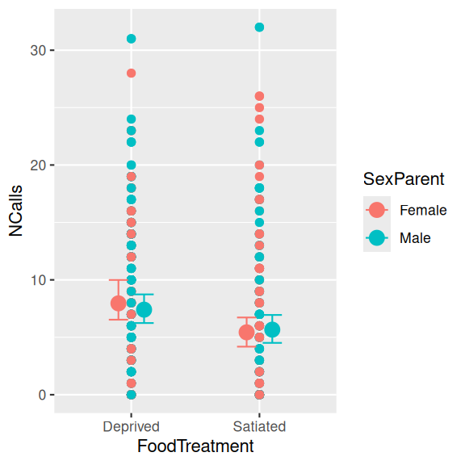

```r
owls_brm4b |>
  conditional_effects("FoodTreatment:SexParent") |>
  plot(points = TRUE)
```

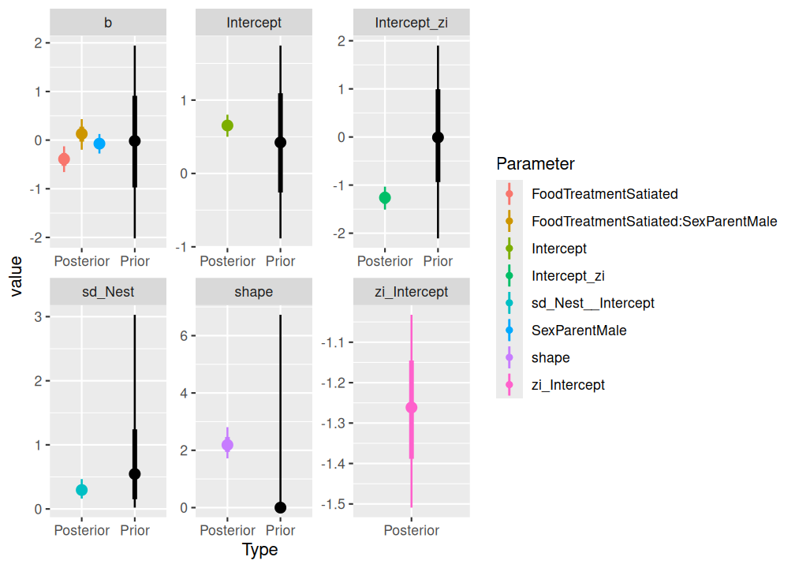

```r
owls_brm4b |> SUYR_prior_and_posterior()
```

**MCMC sampling diagnostics**

```r
owls_brm4b |> get_variables()
```

```
 [1] "b_Intercept"
 [2] "b_zi_Intercept"
 [3] "b_FoodTreatmentSatiated"
 [4] "b_SexParentMale"
 [5] "b_FoodTreatmentSatiated:SexParentMale"
 [6] "sd_Nest__Intercept"
 [7] "shape"
 [8] "Intercept"
 [9] "Intercept_zi"
[10] "r_Nest[AutavauxTV,Intercept]"
[11] "r_Nest[Bochet,Intercept]"
[12] "r_Nest[Champmartin,Intercept]"
[13] "r_Nest[ChEsard,Intercept]"
[14] "r_Nest[Chevroux,Intercept]"
[15] "r_Nest[CorcellesFavres,Intercept]"
```

[output cut: 34 more lines]

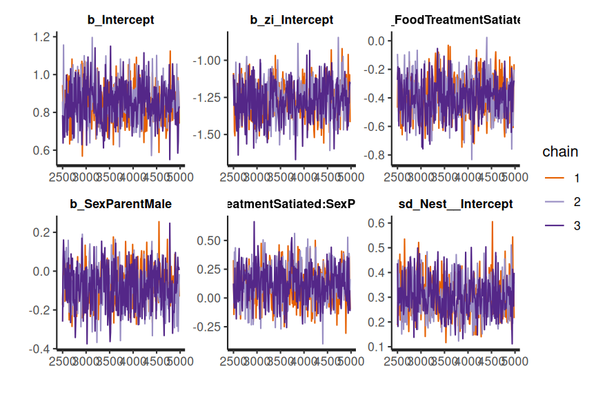

```r
pars <- owls_brm4b |> get_variables()
pars <- str_extract(pars, "^b_.*|^sigma$|^sd.*") |> na.omit()

owls_brm4b$fit |>
  stan_trace(pars = pars)
```

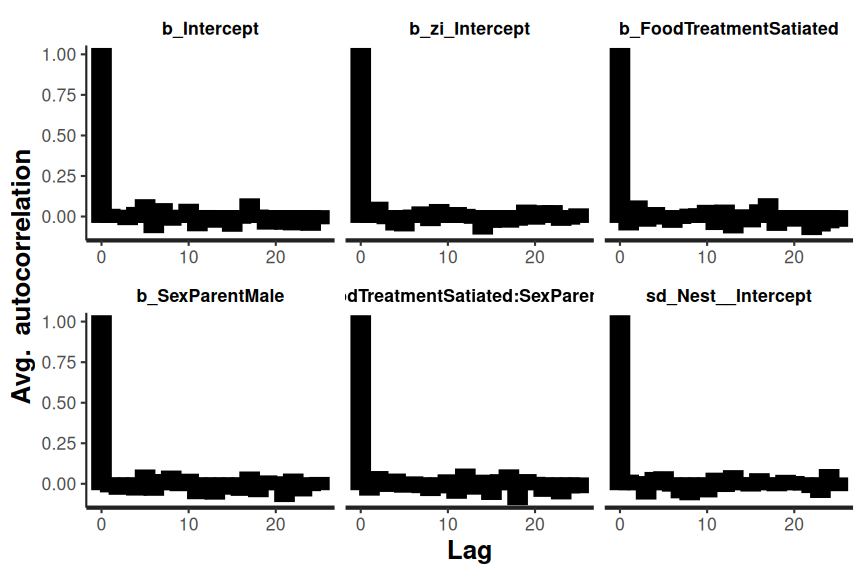

```r
owls_brm4b$fit |>
  stan_ac(pars = pars)
```

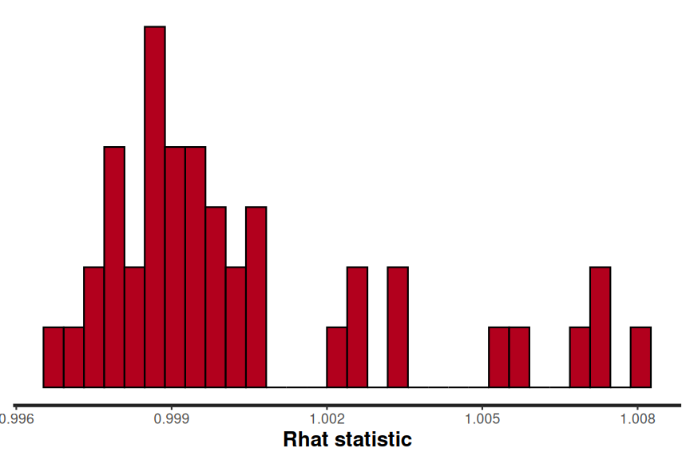

```r
owls_brm4b$fit |> stan_rhat()
```

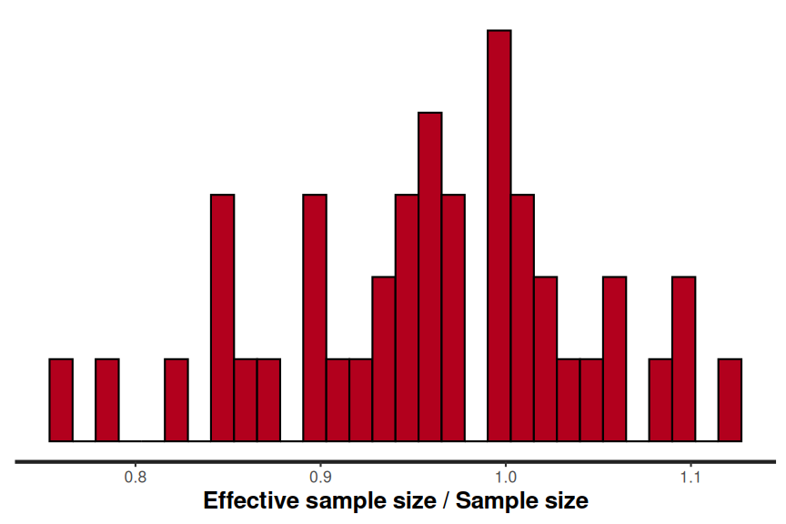

```r
owls_brm4b$fit |> stan_ess()
```

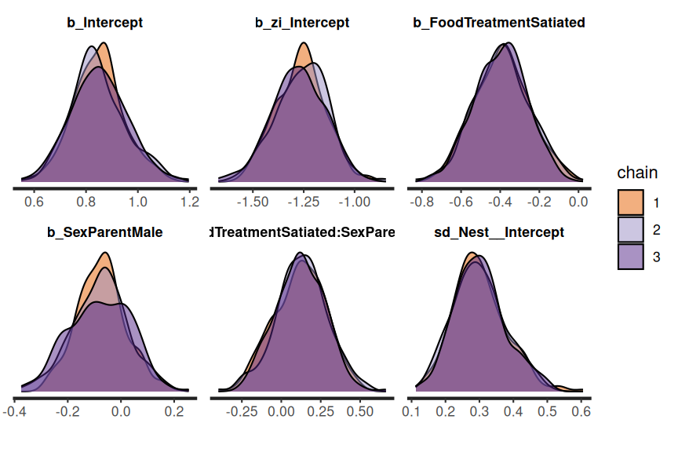

```r
owls_brm4b$fit |>
  stan_dens(separate_chains = TRUE, pars = pars)
```

**Model validation**

**pp check**

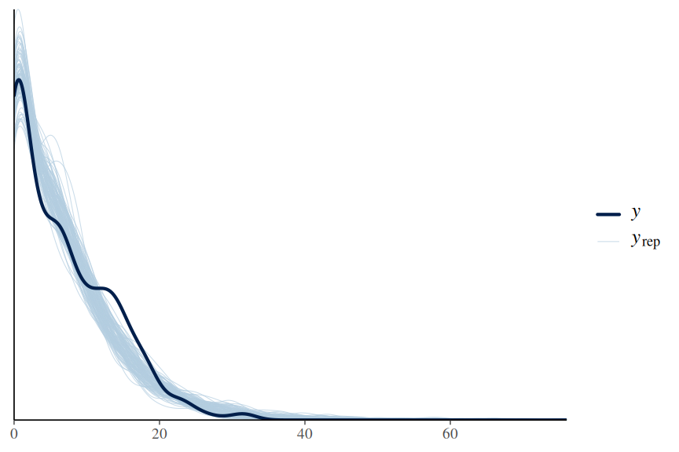

```r
owls_brm4b |> pp_check(type = "dens_overlay", ndraws = 100)
```

```r
## owls_brm4b |> pp_check(type = 'error_scatter_avg')
```

```
Using all posterior draws for ppc type 'intervals' by default.
```

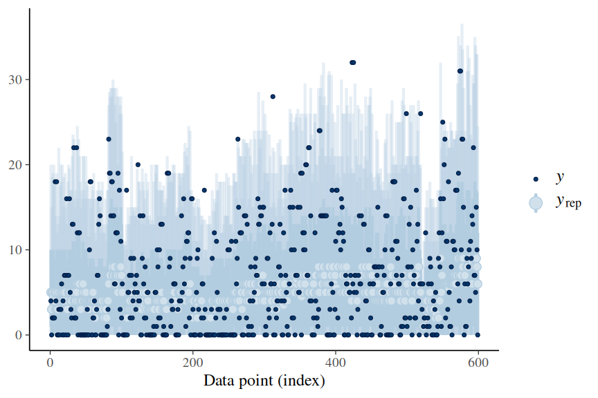

```r
owls_brm4b |> pp_check(group = "Nest", type = "intervals")
```

**DHARMa residuals**

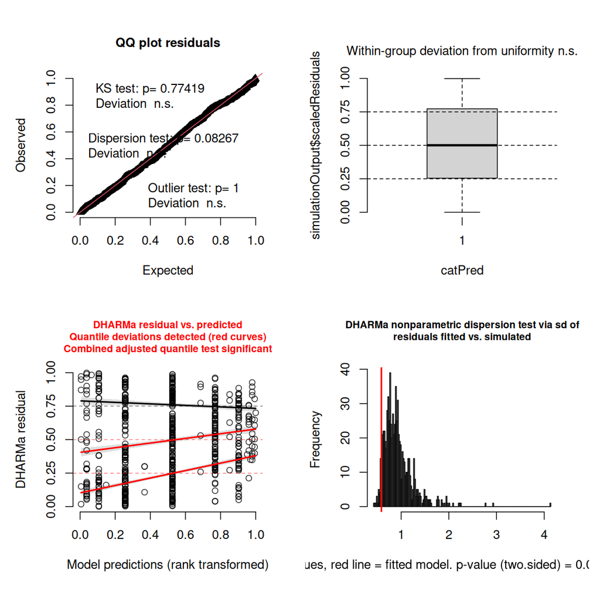

```r
owls_resids <- make_brms_dharma_res(owls_brm4b, integerResponse = TRUE)
wrap_elements(~ testUniformity(owls_resids)) +
  wrap_elements(~ plotResiduals(owls_resids, form = factor(rep(1, nrow(owls))))) +
  wrap_elements(~ plotResiduals(owls_resids, quantreg = TRUE)) +
  wrap_elements(~ testDispersion(owls_resids))
```

**Model 5**

**Fit model**

```r
owls_form <- bf(
  NCalls ~ FoodTreatment * SexParent +
    offset(log(BroodSize)) +
    (FoodTreatment * SexParent | Nest),
  zi = ~ FoodTreatment * SexParent,
  family = zero_inflated_negbinomial(link = "log")
)
options(width = 150)
owls_form |> get_prior(data = owls)
```

```
                               prior     class                                coef group resp dpar nlpar lb ub       source
                              (flat)         b                                                                      default
                              (flat)         b               FoodTreatmentSatiated                             (vectorized)
                              (flat)         b FoodTreatmentSatiated:SexParentMale                             (vectorized)
                              (flat)         b                       SexParentMale                             (vectorized)
                              lkj(1)       cor                                                                      default
                              lkj(1)       cor                                      Nest                       (vectorized)
 student_t(3, 0.16097150412244, 2.5) Intercept                                                                      default
                student_t(3, 0, 2.5)        sd                                                            0         default
                student_t(3, 0, 2.5)        sd                                      Nest                  0    (vectorized)
                student_t(3, 0, 2.5)        sd               FoodTreatmentSatiated  Nest                  0    (vectorized)
                student_t(3, 0, 2.5)        sd FoodTreatmentSatiated:SexParentMale  Nest                  0    (vectorized)
                student_t(3, 0, 2.5)        sd                           Intercept  Nest                  0    (vectorized)
                student_t(3, 0, 2.5)        sd                       SexParentMale  Nest                  0    (vectorized)
                   gamma(0.01, 0.01)     shape                                                            0         default
                              (flat)         b                                                  zi                  default
                              (flat)         b               FoodTreatmentSatiated              zi             (vectorized)
                              (flat)         b FoodTreatmentSatiated:SexParentMale              zi             (vectorized)
                              (flat)         b                       SexParentMale              zi             (vectorized)
                      logistic(0, 1) Intercept                                                  zi                  default
```

```r
options(width = 80)
owls |>
  group_by(FoodTreatment, SexParent) |>
  summarise(
    Mean = log(median(NCalls / BroodSize)),
    SD = log(sd(NCalls / BroodSize)),
    MAD = log(mad(NCalls / BroodSize))
  )
```

```
# A tibble: 4 × 5
# Groups:   FoodTreatment [2]
  FoodTreatment SexParent   Mean    SD    MAD
  <fct>         <fct>      <dbl> <dbl>  <dbl>
1 Deprived      Female     0.405 0.562  0.656
2 Deprived      Male       0.405 0.416  0.489
3 Satiated      Female    -1.23  0.399 -0.838
4 Satiated      Male      -0.511 0.431 -0.117
```

```r
priors <- prior(normal(0.4, 0.7), class = "Intercept") +
  prior(normal(0, 1), class = "b") +
  prior(student_t(3, 0, 0.7), class = "sd") +
  prior(normal(0, 1), class = "Intercept", dpar = "zi") +
  prior(normal(0, 1), class = "b", dpar = "zi") +
  prior(gamma(0.01, 0.01), class = "shape")
owls_brm5a <- brm(owls_form,
  data = owls,
  prior = priors,
  sample_prior = "only",
  iter = 5000,
  warmup = 2500,
  chains = 3,
  cores = 3,
  thin = 10,
  refresh = 0,
  seed = 123,
  control = list(adapt_delta = 0.99),
  backend = "rstan"
)
```

```r
owls_brm5b <- update(owls_brm5a,
  sample_prior = "yes",
  iter = 5000,
  warmup = 2500,
  control = list(adapt_delta = 0.99, max_treedepth = 20),
  backend = "rstan",
  refresh = 0
)
```

```
The desired updates require recompiling the model
```

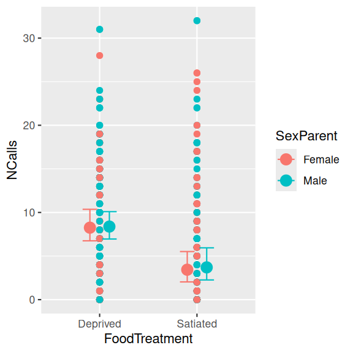

```r
owls_brm5b |>
  conditional_effects("FoodTreatment:SexParent") |>
  plot(points = TRUE)
```

```r
## owls_brm5b |> SUYR_prior_and_posterior()
```

**MCMC sampling diagnostics**

```r
owls_brm5b |> get_variables()
```

```
  [1] "b_Intercept"
  [2] "b_zi_Intercept"
  [3] "b_FoodTreatmentSatiated"
  [4] "b_SexParentMale"
  [5] "b_FoodTreatmentSatiated:SexParentMale"
  [6] "b_zi_FoodTreatmentSatiated"
  [7] "b_zi_SexParentMale"
  [8] "b_zi_FoodTreatmentSatiated:SexParentMale"
  [9] "sd_Nest__Intercept"
 [10] "sd_Nest__FoodTreatmentSatiated"
 [11] "sd_Nest__SexParentMale"
 [12] "sd_Nest__FoodTreatmentSatiated:SexParentMale"
 [13] "cor_Nest__Intercept__FoodTreatmentSatiated"
 [14] "cor_Nest__Intercept__SexParentMale"
 [15] "cor_Nest__FoodTreatmentSatiated__SexParentMale"
```

[output cut: 129 more lines]

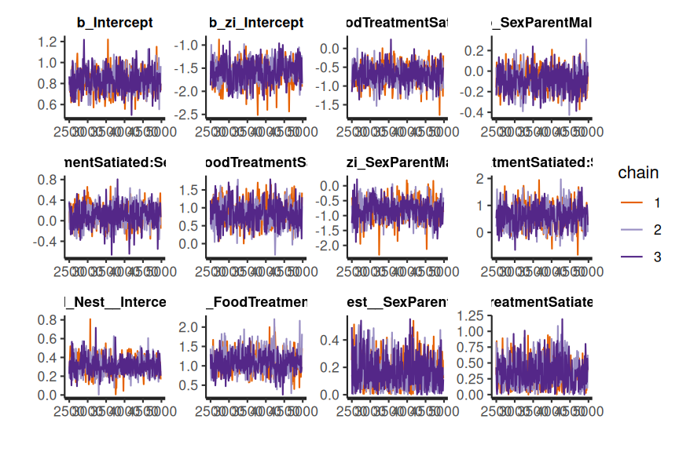

```r
pars <- owls_brm5b |> get_variables()
pars <- str_extract(pars, "^b_.*|^sigma$|^sd.*") |> na.omit()

owls_brm5b$fit |>
  stan_trace(pars = pars)
```

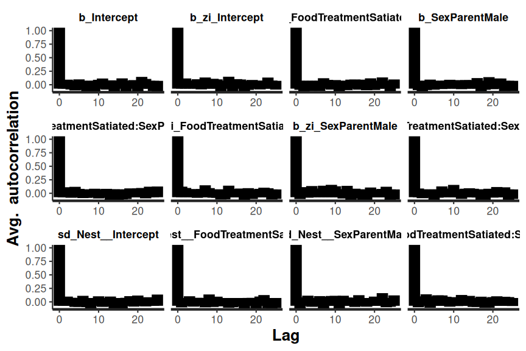

```r
owls_brm5b$fit |>
  stan_ac(pars = pars)
```

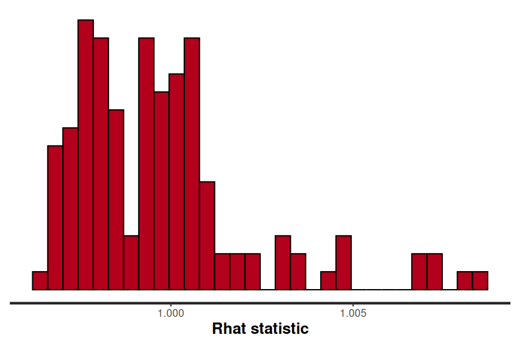

```r
owls_brm5b$fit |> stan_rhat()
```

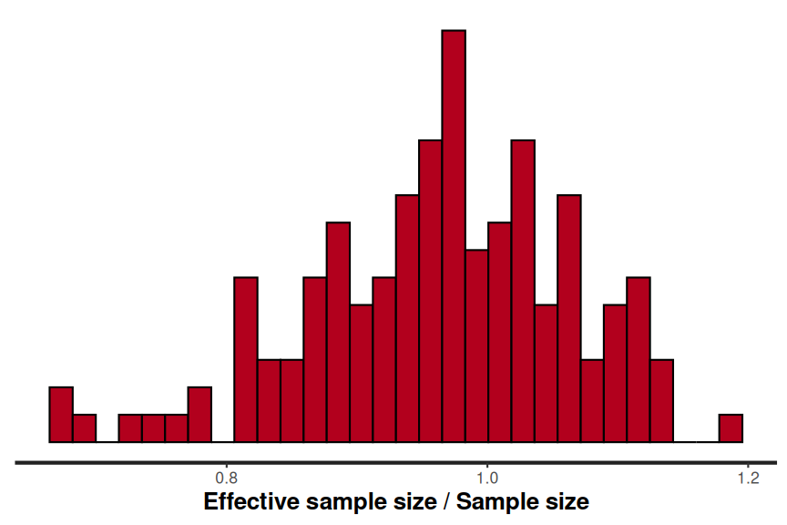

```r
owls_brm5b$fit |> stan_ess()
```

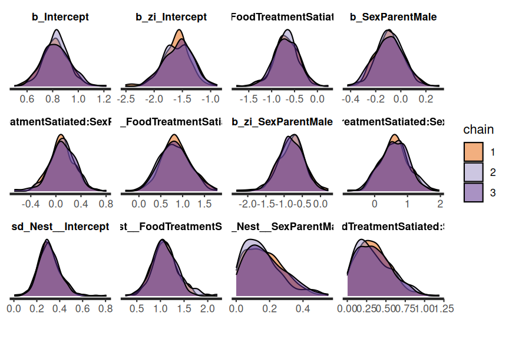

```r
owls_brm5b$fit |>
  stan_dens(separate_chains = TRUE, pars = pars)
```

**Model validation**

**pp check**

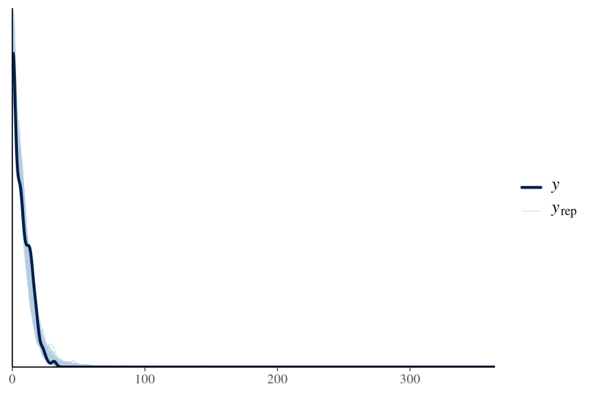

```r
owls_brm5b |> pp_check(type = "dens_overlay", ndraws = 100)
```

```r
## owls_brm5b |> pp_check(type = 'error_scatter_avg')
```

```
Using all posterior draws for ppc type 'intervals' by default.
```

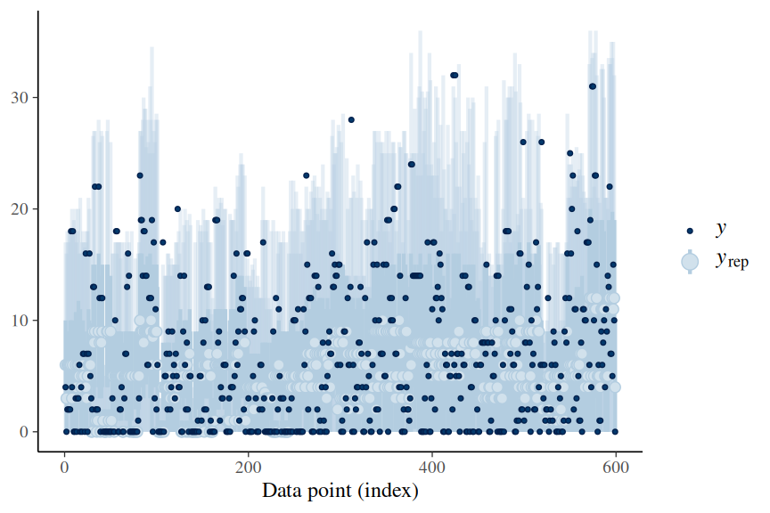

```r
owls_brm5b |> pp_check(group = "Nest", type = "intervals")
```

**DHARMa residuals**

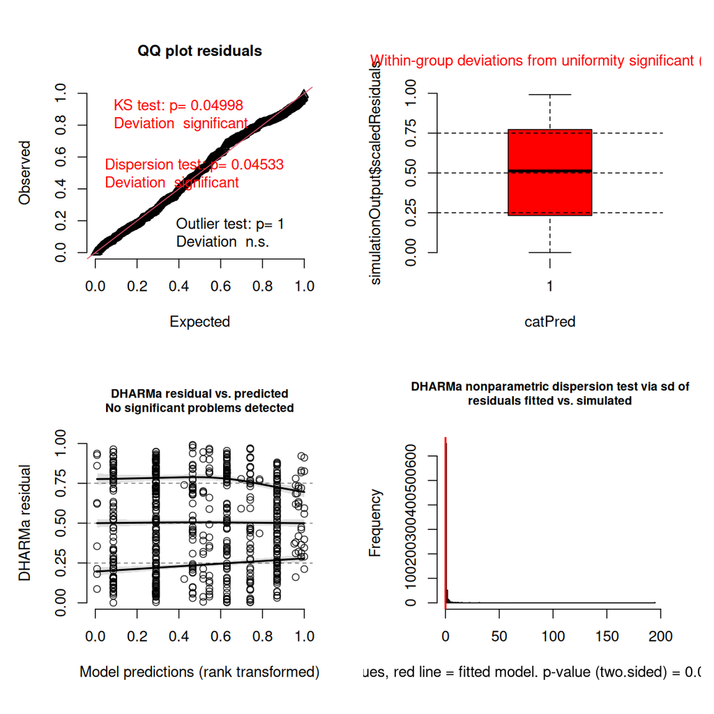

```r
owls_resids <- make_brms_dharma_res(owls_brm5b, integerResponse = TRUE)
wrap_elements(~ testUniformity(owls_resids)) +
  wrap_elements(~ plotResiduals(owls_resids, form = factor(rep(1, nrow(owls))))) +
  wrap_elements(~ plotResiduals(owls_resids, quantreg = TRUE)) +
  wrap_elements(~ testDispersion(owls_resids))
```

**Comparisons**

```r
(loo_3 <- loo::loo(owls_brm3b))
```

```
Computed from 750 by 599 log-likelihood matrix.

         Estimate   SE
elpd_loo  -1714.5 26.9
p_loo        17.9  1.5
looic      3429.0 53.8
------
MCSE of elpd_loo is 0.2.
MCSE and ESS estimates assume MCMC draws (r_eff in [0.8, 1.2]).

All Pareto k estimates are good (k < 0.65).
See help('pareto-k-diagnostic') for details.
```

```r
(loo_4 <- loo::loo(owls_brm4b))
```

```
Computed from 750 by 599 log-likelihood matrix.

         Estimate   SE
elpd_loo  -1709.9 27.4
p_loo        23.0  2.3
looic      3419.8 54.8
------
MCSE of elpd_loo is NA.
MCSE and ESS estimates assume MCMC draws (r_eff in [0.6, 1.2]).

Pareto k diagnostic values:
                          Count Pct.    Min. ESS
(-Inf, 0.65]   (good)     598   99.8%   248
   (0.65, 1]   (bad)        1    0.2%   <NA>
    (1, Inf)   (very bad)   0    0.0%   <NA>
See help('pareto-k-diagnostic') for details.
```

```r
(loo_5 <- loo::loo(owls_brm5b))
```

```
Computed from 750 by 599 log-likelihood matrix.

         Estimate   SE
elpd_loo  -1656.8 29.0
p_loo        50.0  4.0
looic      3313.6 58.0
------
MCSE of elpd_loo is NA.
MCSE and ESS estimates assume MCMC draws (r_eff in [0.6, 1.2]).

Pareto k diagnostic values:
                          Count Pct.    Min. ESS
(-Inf, 0.65]   (good)     592   98.8%   82
   (0.65, 1]   (bad)        7    1.2%   <NA>
    (1, Inf)   (very bad)   0    0.0%   <NA>
See help('pareto-k-diagnostic') for details.
```

```r
loo::loo_compare(loo_3, loo_4, loo_5)
```

```
           elpd_diff se_diff
owls_brm5b   0.0       0.0
owls_brm4b -53.1       9.1
owls_brm3b -57.7       9.8
```

Conclusions: - evidently, the zero-inflated negative binomial model with random intercepts/slopes (owls_brm5b) is the best model…